# Week 4 - Simulation & Profiling

# Week 4 - Simulation & Profiling

## The str Function

str: Completly display the internal structyure of an R object

- A diagnostic function and an alternative to ‘summary’
- It is especially well suited to compactly display the (abbreviated) contents of (spossibly nester) lists.
- Roughly one line per basic object

```r
str(str)
```

```
function (object, ...)
```

```r
str(lm)
```

```
function (formula, data, subset, weights, na.action, method = "qr", model = TRUE, x = FALSE, y = FALSE,
    qr = TRUE, singular.ok = TRUE, contrasts = NULL, offset, ...)
```

```r
x <- rnorm(100, 2, 4)
x
```

```
  [1]  0.67889824 -7.22563344  6.02677455  2.00027274  6.81534444 -1.21981611 -0.95419170  3.09211241
  [9]  6.34410946 -0.78312988  3.65185280  0.49500688  8.98078786 -3.25105229  5.52084655  8.90585610
 [17]  2.22098708  2.91297093  9.16969283  5.79520551  6.29332708 -1.91292146  3.33878836 -4.19974955
 [25]  8.02945293 -3.49897794  2.92391798 -2.35277406  0.07994166 15.39113536  4.14499075  3.90705059
 [33]  3.96109146  1.00958886  2.71374858 -1.06463702  3.51276424  7.17874842 -1.13170723 -0.78552799
 [41]  2.23605838  2.60952195  3.29853835  4.67687124 -0.16367614 -2.73798321 -0.68714959 -0.68985204
 [49]  0.66539134  4.55326408  2.58389834  0.62283251  0.66222746  7.19862925  4.09389750  2.48086234
 [57]  4.46848407  0.29660934  2.61145343  5.19881568  3.61194897 -4.01098380  5.45991197 -0.88791534
 [65] -1.43785596  5.57435494 -4.07381307 -0.80236688 -1.13797670  4.25269177  5.22424081 -1.31068098
 [73]  1.71732855  7.24595956  1.42391414 -6.29636741  1.03143189 -3.43315097  6.72418039  6.30247159
 [81] -0.11117085 -6.00077901  1.19384905  2.63007147  2.31531535  5.80387918 -2.36678823  2.14260115
 [89]  6.28694475  2.75673374  5.84932956  4.12895560 -6.20799835 -0.84915357 10.26547839  5.50594856
 [97]  8.24002967  3.05142158 -2.70077427  6.87154088
```

```r
summary(x)
```

```
   Min. 1st Qu.  Median    Mean 3rd Qu.    Max.
-7.2256 -0.7897  2.5967  2.2468  5.2832 15.3911
```

```r
str(x)
```

```
 num [1:100] 0.679 -7.226 6.027 2 6.815 ...
```

x is a numeric vector, has 100 elements in it, and gives first 5 elements.

```r
f <- gl(40,10)
str(f)
```

```
 Factor w/ 40 levels "1","2","3","4",..: 1 1 1 1 1 1 1 1 1 1 ...
```

```r
summary(f)
```

```
 1  2  3  4  5  6  7  8  9 10 11 12 13 14 15 16 17 18 19 20 21 22 23 24 25 26 27 28 29 30 31 32 33 34 35
10 10 10 10 10 10 10 10 10 10 10 10 10 10 10 10 10 10 10 10 10 10 10 10 10 10 10 10 10 10 10 10 10 10 10
36 37 38 39 40
10 10 10 10 10
```

```r
library(datasets)
head(airquality)
```

|  | Ozone | Solar.R | Wind | Temp | Month | Day |
| --- | --- | --- | --- | --- | --- | --- |
| 1 | 41 | 190 | 7.4 | 67 | 5 | 1 |
| 2 | 36 | 118 | 8.0 | 72 | 5 | 2 |
| 3 | 12 | 149 | 12.6 | 74 | 5 | 3 |
| 4 | 18 | 313 | 11.5 | 62 | 5 | 4 |
| 5 | NA | NA | 14.3 | 56 | 5 | 5 |
| 6 | 28 | NA | 14.9 | 66 | 5 | 6 |

```r
str(airquality)
```

```
'data.frame':   153 obs. of  6 variables:
 $ Ozone  : int  41 36 12 18 NA 28 23 19 8 NA ...
 $ Solar.R: int  190 118 149 313 NA NA 299 99 19 194 ...
 $ Wind   : num  7.4 8 12.6 11.5 14.3 14.9 8.6 13.8 20.1 8.6 ...
 $ Temp   : int  67 72 74 62 56 66 65 59 61 69 ...
 $ Month  : int  5 5 5 5 5 5 5 5 5 5 ...
 $ Day    : int  1 2 3 4 5 6 7 8 9 10 ...
```

```r
m <- matrix(rnorm(100,10,10))
str(m)
```

```
 num [1:100, 1] 14.52 9.61 8.4 13.22 17.5 ...
```

```r
m[,1]
```

```
  [1]  14.51885669   9.61413380   8.39905864  13.22190170  17.50335703   4.20569536   9.16456844
  [8]  15.16374732  13.05730160 -12.96574559  35.75665082   7.37816298   3.66403297  12.54493902
 [15]   7.68150292   5.06976882  16.26873949  25.33163640  19.87011570  12.07644267  14.46665509
 [22]  22.19078429  13.83936323 -10.10875987  -2.99913082   7.30178461  13.14267776  -2.56777949
 [29]  10.46308761  -6.06837830  12.41374580  -7.17618279   7.84840480  12.42073388  12.00168413
 [36]  15.21788678   4.35640292  -3.46546840   1.53793730   8.71151532  -3.71545380   1.36818758
 [43]  12.93348595  11.09641197  21.50191883  14.99197735   1.29321210   6.63280219  18.54882088
 [50]  11.57097132   0.08285488   7.71830549  -0.98856916  15.87511714  24.35932028  -4.60650282
 [57]   8.09533594   9.80632508   1.71470787  15.75604326  22.71145880   2.92918505   5.21624075
 [64]  12.46213152   5.23981146  -4.67499668  32.28687791   3.78660016  28.66806038  22.36827113
 [71]  11.93783042   9.55649698  14.49915276  27.10291920  21.25478712  18.81946853  25.11472967
 [78]  22.48503711  18.49197715  13.24002661   4.47941261  14.34377756   1.28446465   4.24451482
 [85]  11.62863689 -17.61809932   9.44368085   6.01284849  29.64116099   8.06244172  11.13107052
 [92]   3.62535732  23.93933627   4.83711590  13.06199854  -6.61601029  12.93281520  13.77154523
 [99]  22.59037506   9.17027202
```

```r
s <- split(airquality, airquality$Month)
s
```

```
$`5`
```

|  | Ozone | Solar.R | Wind | Temp | Month | Day |
| --- | --- | --- | --- | --- | --- | --- |
| 1 | 41 | 190 | 7.4 | 67 | 5 | 1 |
| 2 | 36 | 118 | 8.0 | 72 | 5 | 2 |
| 3 | 12 | 149 | 12.6 | 74 | 5 | 3 |
| 4 | 18 | 313 | 11.5 | 62 | 5 | 4 |
| 5 | NA | NA | 14.3 | 56 | 5 | 5 |
| 6 | 28 | NA | 14.9 | 66 | 5 | 6 |
| 7 | 23 | 299 | 8.6 | 65 | 5 | 7 |
| 8 | 19 | 99 | 13.8 | 59 | 5 | 8 |
| 9 | 8 | 19 | 20.1 | 61 | 5 | 9 |
| 10 | NA | 194 | 8.6 | 69 | 5 | 10 |

[output cut: 21 more lines]

```
$`6`
```

|  | Ozone | Solar.R | Wind | Temp | Month | Day |
| --- | --- | --- | --- | --- | --- | --- |
| 32 | NA | 286 | 8.6 | 78 | 6 | 1 |
| 33 | NA | 287 | 9.7 | 74 | 6 | 2 |
| 34 | NA | 242 | 16.1 | 67 | 6 | 3 |
| 35 | NA | 186 | 9.2 | 84 | 6 | 4 |
| 36 | NA | 220 | 8.6 | 85 | 6 | 5 |
| 37 | NA | 264 | 14.3 | 79 | 6 | 6 |
| 38 | 29 | 127 | 9.7 | 82 | 6 | 7 |
| 39 | NA | 273 | 6.9 | 87 | 6 | 8 |
| 40 | 71 | 291 | 13.8 | 90 | 6 | 9 |
| 41 | 39 | 323 | 11.5 | 87 | 6 | 10 |

[output cut: 20 more lines]

```
$`7`
```

|  | Ozone | Solar.R | Wind | Temp | Month | Day |
| --- | --- | --- | --- | --- | --- | --- |
| 62 | 135 | 269 | 4.1 | 84 | 7 | 1 |
| 63 | 49 | 248 | 9.2 | 85 | 7 | 2 |
| 64 | 32 | 236 | 9.2 | 81 | 7 | 3 |
| 65 | NA | 101 | 10.9 | 84 | 7 | 4 |
| 66 | 64 | 175 | 4.6 | 83 | 7 | 5 |
| 67 | 40 | 314 | 10.9 | 83 | 7 | 6 |
| 68 | 77 | 276 | 5.1 | 88 | 7 | 7 |
| 69 | 97 | 267 | 6.3 | 92 | 7 | 8 |
| 70 | 97 | 272 | 5.7 | 92 | 7 | 9 |
| 71 | 85 | 175 | 7.4 | 89 | 7 | 10 |

[output cut: 21 more lines]

```
$`8`
```

|  | Ozone | Solar.R | Wind | Temp | Month | Day |
| --- | --- | --- | --- | --- | --- | --- |
| 93 | 39 | 83 | 6.9 | 81 | 8 | 1 |
| 94 | 9 | 24 | 13.8 | 81 | 8 | 2 |
| 95 | 16 | 77 | 7.4 | 82 | 8 | 3 |
| 96 | 78 | NA | 6.9 | 86 | 8 | 4 |
| 97 | 35 | NA | 7.4 | 85 | 8 | 5 |
| 98 | 66 | NA | 4.6 | 87 | 8 | 6 |
| 99 | 122 | 255 | 4.0 | 89 | 8 | 7 |
| 100 | 89 | 229 | 10.3 | 90 | 8 | 8 |
| 101 | 110 | 207 | 8.0 | 90 | 8 | 9 |
| 102 | NA | 222 | 8.6 | 92 | 8 | 10 |

[output cut: 21 more lines]

```
$`9`
```

|  | Ozone | Solar.R | Wind | Temp | Month | Day |
| --- | --- | --- | --- | --- | --- | --- |
| 124 | 96 | 167 | 6.9 | 91 | 9 | 1 |
| 125 | 78 | 197 | 5.1 | 92 | 9 | 2 |
| 126 | 73 | 183 | 2.8 | 93 | 9 | 3 |
| 127 | 91 | 189 | 4.6 | 93 | 9 | 4 |
| 128 | 47 | 95 | 7.4 | 87 | 9 | 5 |
| 129 | 32 | 92 | 15.5 | 84 | 9 | 6 |
| 130 | 20 | 252 | 10.9 | 80 | 9 | 7 |
| 131 | 23 | 220 | 10.3 | 78 | 9 | 8 |
| 132 | 21 | 230 | 10.9 | 75 | 9 | 9 |
| 133 | 24 | 259 | 9.7 | 73 | 9 | 10 |

[output cut: 20 more lines]

```
NA
```

```r
str(s)
```

```
List of 5
 $ 5:'data.frame':  31 obs. of  6 variables:
  ..$ Ozone  : int [1:31] 41 36 12 18 NA 28 23 19 8 NA ...
  ..$ Solar.R: int [1:31] 190 118 149 313 NA NA 299 99 19 194 ...
  ..$ Wind   : num [1:31] 7.4 8 12.6 11.5 14.3 14.9 8.6 13.8 20.1 8.6 ...
  ..$ Temp   : int [1:31] 67 72 74 62 56 66 65 59 61 69 ...
  ..$ Month  : int [1:31] 5 5 5 5 5 5 5 5 5 5 ...
  ..$ Day    : int [1:31] 1 2 3 4 5 6 7 8 9 10 ...
 $ 6:'data.frame':  30 obs. of  6 variables:
  ..$ Ozone  : int [1:30] NA NA NA NA NA NA 29 NA 71 39 ...
  ..$ Solar.R: int [1:30] 286 287 242 186 220 264 127 273 291 323 ...
  ..$ Wind   : num [1:30] 8.6 9.7 16.1 9.2 8.6 14.3 9.7 6.9 13.8 11.5 ...
  ..$ Temp   : int [1:30] 78 74 67 84 85 79 82 87 90 87 ...
  ..$ Month  : int [1:30] 6 6 6 6 6 6 6 6 6 6 ...
  ..$ Day    : int [1:30] 1 2 3 4 5 6 7 8 9 10 ...
 $ 7:'data.frame':  31 obs. of  6 variables:
  ..$ Ozone  : int [1:31] 135 49 32 NA 64 40 77 97 97 85 ...
  ..$ Solar.R: int [1:31] 269 248 236 101 175 314 276 267 272 175 ...
  ..$ Wind   : num [1:31] 4.1 9.2 9.2 10.9 4.6 10.9 5.1 6.3 5.7 7.4 ...
  ..$ Temp   : int [1:31] 84 85 81 84 83 83 88 92 92 89 ...
  ..$ Month  : int [1:31] 7 7 7 7 7 7 7 7 7 7 ...
  ..$ Day    : int [1:31] 1 2 3 4 5 6 7 8 9 10 ...
 $ 8:'data.frame':  31 obs. of  6 variables:
  ..$ Ozone  : int [1:31] 39 9 16 78 35 66 122 89 110 NA ...
  ..$ Solar.R: int [1:31] 83 24 77 NA NA NA 255 229 207 222 ...
  ..$ Wind   : num [1:31] 6.9 13.8 7.4 6.9 7.4 4.6 4 10.3 8 8.6 ...
  ..$ Temp   : int [1:31] 81 81 82 86 85 87 89 90 90 92 ...
  ..$ Month  : int [1:31] 8 8 8 8 8 8 8 8 8 8 ...
  ..$ Day    : int [1:31] 1 2 3 4 5 6 7 8 9 10 ...
 $ 9:'data.frame':  30 obs. of  6 variables:
  ..$ Ozone  : int [1:30] 96 78 73 91 47 32 20 23 21 24 ...
  ..$ Solar.R: int [1:30] 167 197 183 189 95 92 252 220 230 259 ...
  ..$ Wind   : num [1:30] 6.9 5.1 2.8 4.6 7.4 15.5 10.9 10.3 10.9 9.7 ...
  ..$ Temp   : int [1:30] 91 92 93 93 87 84 80 78 75 73 ...
  ..$ Month  : int [1:30] 9 9 9 9 9 9 9 9 9 9 ...
  ..$ Day    : int [1:30] 1 2 3 4 5 6 7 8 9 10 ...
```

## Simulation - Generating Random Numbers

Functions for probability distributions in R

· rnorm: generate random Normal variates with a given mean and standard deviation · dnorm: evaluate the Normal probability density (with a given mean/SD) at a point (or vector of points) · pnorm: evaluate the cumulative distribution function for a Normal distribution · rpois: generate random Poisson variates with a given rate

Probability distribution functions usually have four functions associated with them. The functions are prefixed with a · d for density · r for random number generation · p for cumulative distribution · q for quantile function

Working with the Normal distributions requires using these four functions

```
dnorm(x, mean = 0, sd = 1, log = FALSE)
pnorm(q, mean = 0, sd = 1, lower.tail = TRUE, log.p = FALSE)
qnorm(p, mean = 0, sd = 1, lower.tail = TRUE, log.p = FALSE)
rnorm(n, mean = 0, sd = 1)
```

If Φ is the cumulative distribution function for a standard Normal distribution, then pnorm(q) = Φ(q) and qnorm(p) = Φ−1 (p).

```r
x <- rnorm(10)
x
```

```
 [1]  0.1882134  0.3603557  2.0685363 -0.6285388  0.1768529 -1.0042016 -0.9337095 -0.9746794 -1.9840149
[10]  0.5837560
```

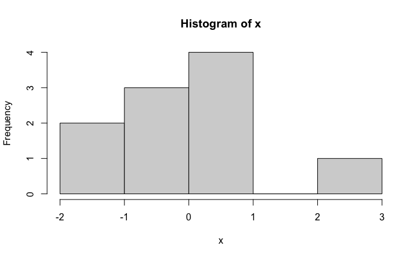

```r
hist(x)
```

```r
x <- rnorm(10,20,2)
x
```

```
 [1] 21.62608 19.44399 19.92630 19.36711 20.10980 19.20915 21.62584 23.31885 18.58681 21.58356
```

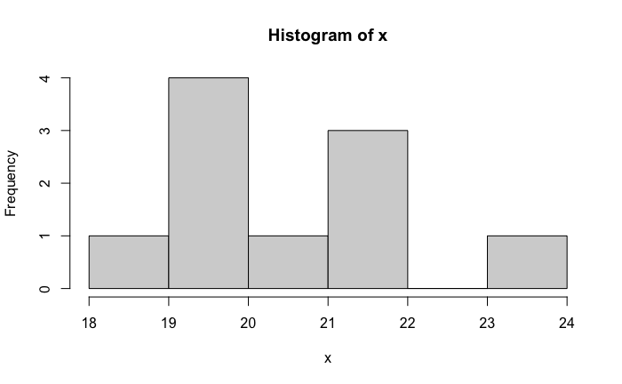

```r
hist(x)
```

```r
summary(x)
```

```
   Min. 1st Qu.  Median    Mean 3rd Qu.    Max.
  18.59   19.39   20.02   20.48   21.62   23.32
```

Setting the random number seed with set.seed ensures reproducibility

```r
set.seed(1)
rnorm(5)
```

```
[1] -0.6264538  0.1836433 -0.8356286  1.5952808  0.3295078
```

```r
rnorm(5)
```

```
[1] -0.8204684  0.4874291  0.7383247  0.5757814 -0.3053884
```

```r
set.seed(1)
rnorm(5)
```

```
[1] -0.6264538  0.1836433 -0.8356286  1.5952808  0.3295078
```

Always set the random number seed when conducting a simulation!

Generating Poisson data

```r
rpois(10, 1)
```

```
 [1] 0 0 1 1 2 1 1 4 1 2
```

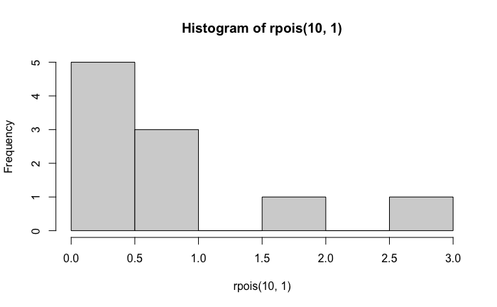

```r
hist(rpois(10, 1))
```

```r
rpois(10, 20)
```

```
 [1] 19 19 24 23 22 24 23 20 11 22
```

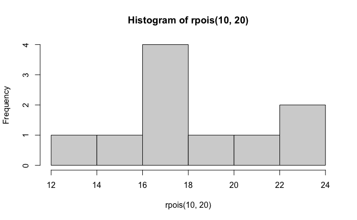

```r
hist(rpois(10, 20))
```

```r
ppois(2, 2) ## Cumulative distribution
```

```
[1] 0.6766764
```

Pr(x <= 2)

```r
ppois(6, 2)
```

```
[1] 0.9954662
```

Pr(x <= 6)

```r
ppois(4, 2)
```

```
[1] 0.947347
```

Pr(x <= 4)

### Generating Random Numbers From a Linear Model

Suppose we want to simulate from the following linear model

y=β0 +β1x+ε

where ε ∼ N(0,22). Assume x ∼ N(0,12), β0 = 0.5 and β1 = 2.

```r
set.seed(20)
x <- rnorm(100)
e <- rnorm(100, 0, 2)
y<-0.5+2*x+e
```

```r
summary(y)
```

```
   Min. 1st Qu.  Median    Mean 3rd Qu.    Max.
-6.4084 -1.5402  0.6789  0.6893  2.9303  6.5052
```

```r
y
```

```
  [1]  3.92145671 -1.12306154  6.50516206 -0.76334657  1.43080733  1.85824578 -5.49942000 -2.10701153
  [9]  0.67867568 -3.64118829  2.15300374  3.64495611 -2.65751679  0.04553572 -3.72883351 -2.23668198
 [17] -0.49039654  4.38887620  0.16890419  0.52829153  2.48205656  0.76639727  4.04713057  4.48476280
 [25]  1.63952492 -1.71150396  0.67914445 -5.37113780 -5.81140592 -2.71828488 -2.12810590  6.02056165
 [33]  0.60895238  6.05517659 -4.71161217 -4.39467489 -2.65861895  3.58184381 -1.50917314  3.20076678
 [41] -1.76509940 -3.28807288  2.19238717  2.55958594 -2.08720395  0.70189574  2.69534679  6.09139163
 [49]  1.59929020 -1.02936781  4.84828910 -1.27631332  2.51707303 -0.08880639  4.27076653  1.54675806
 [57]  2.42362336 -0.60750392 -0.57008476  4.32189399  2.69160962  1.02230623  2.38639291 -0.58044205
 [65]  4.83151620 -6.40843800  2.11701166 -0.17304283  5.42106533 -1.48483428  2.77113330  0.20767705
 [73]  3.66166652 -1.98363440  0.28360591 -1.48370020 -2.76032486  0.32931957  0.47189300 -0.34351008
 [81]  0.28078066  5.21035478  1.00142931  4.20158959  3.09853964  1.93979202  3.26573037  1.30890176
 [89]  3.39689480  0.96975660  6.27609452 -5.76983364 -1.63342938 -2.21466670  0.51530957 -2.51624067
 [97]  3.50519076  4.40940115 -2.85087510  2.87426339
```

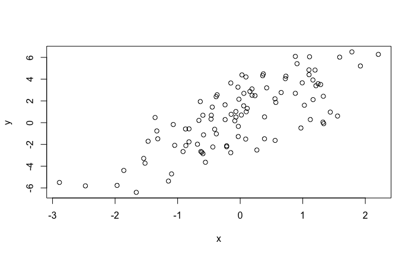

```r
plot(x, y)
```

What if x is binary?

```r
set.seed(10)
x <- rbinom(100, 1, 0.5)
e <- rnorm(100, 0, 2)
y<-0.5+2*x+e
y
```

```
  [1]  1.698724906 -0.169113130  3.235907906  6.775534207  1.511638529  2.072684768 -1.304423888
  [8]  1.565793985  1.208211493  1.081974977  0.024811062  1.587647450 -1.160645309  3.180231287
 [15]  2.632752791  2.932251676  1.971381315 -0.462417235  1.625489526  0.007360576  3.261844425
 [22] -0.360854506  0.403108990  0.062992899 -2.479872473  4.845412562 -0.459654043 -0.360775632
 [29]  0.396722716  3.545172688  3.685656109  0.054676982  1.925788552  3.933201667  1.380483729
 [36]  2.817661243  3.819528277  6.941039326  0.132109852  2.352088331 -0.332709350  0.117035312
 [43]  0.639089563  4.810696636  1.689914694 -2.339290217 -2.713354491  2.285851799  0.796335910
 [50]  4.954056780 -1.023608678  3.338750812 -1.579886729  1.923147932 -0.766426030  3.626349329
 [57]  1.821973372 -2.816101715  2.556335954  4.755907228 -2.060309207  2.757736455 -0.428269054
 [64] -0.131520419  4.348586294  2.654289448  4.579847210  1.983772413  3.011089717  2.401837933
 [71] -0.462731215  2.905763556  2.436520512  0.108839399  1.747362474  0.670391033  0.997516015
 [78]  0.374754414 -0.227964494 -1.913989707  5.358425563  1.766871782 -3.493631235  1.136335654
 [85] -0.420110959 -1.466138388  3.490663426  1.951635000  1.834597464  2.409572873 -2.850664359
 [92]  0.089629215 -1.426504978  5.441504620  1.244944677  4.631758668  1.561299737  2.703966892
 [99]  5.175564932  0.674469537
```

```r
summary(y)
```

```
   Min. 1st Qu.  Median    Mean 3rd Qu.    Max.
-3.4936 -0.1409  1.5767  1.4322  2.8397  6.9410
```

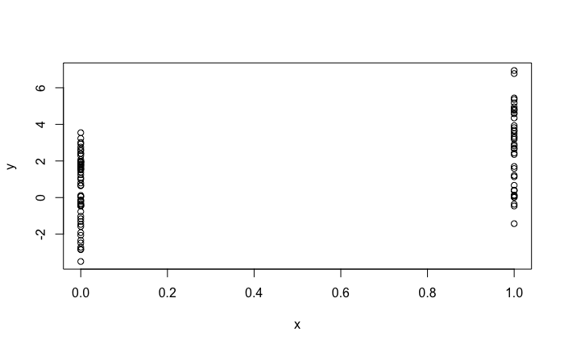

```r
plot(x,y)
```

Suppose we want to simulate from a Poisson model where

Y ~ Poisson(μ) logμ=β0 +β1x

and β0 = 0.5 and β1 = 0.3. We need to use the rpois function for this

```r
set.seed(1)
x <- rnorm(100)
log.mu<-0.5+0.3*x
y <- rpois(100, exp(log.mu))
summary(y)
```

```
   Min. 1st Qu.  Median    Mean 3rd Qu.    Max.
   0.00    1.00    1.00    1.55    2.00    6.00
```

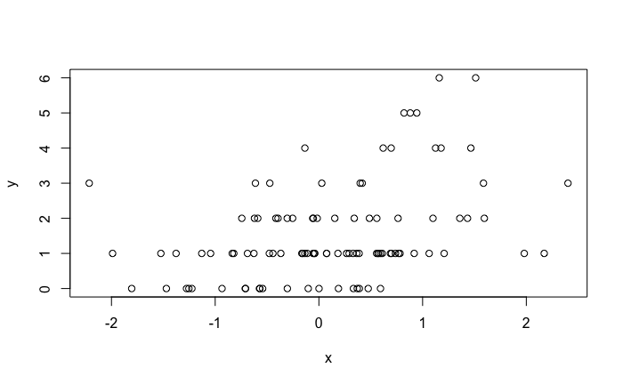

```r
plot(x,y)
```